# Seventh Week: Generalized Linear Models

Murder or suicide

Yasmin Sarcheshmehpour 94109827

2018-04-27 23:57:49

> با توجه به سوالات مرگ و میر در آمریکا به سوالات زیر پاسخ دهید.

۱. از میان متغیرهای داده مرگ و میر یک زیرمجموعه ایی بدون حشو در نظر بگیرید. ماتریس همبستگی متغیرهای مختلف را به دست آورده و سپس رسم نمایید. علاوه بر این نمودار پراکنش متغیرهای انتخاب شده را همزمان نسبت به هم رسم نمایید.

```r
selected_fields = c('ResidentStatus', 'EducationReportingFlag', 'Sex', 'Age', 'PlaceOfDeathAndDecedentsStatus', 'MaritalStatus', 'MethodOfDisposition', 'Autopsy', 'ActivityCode', 'PlaceOfInjury', 'Race', 'suicide')
selecdted_data = death[, selected_fields]
selecdted_data[, 'MaritalStatus'] = as.numeric(selecdted_data[, 'MaritalStatus'])
selecdted_data[, 'Sex'] = as.numeric(selecdted_data[, 'Sex'])
selecdted_data[, 'Autopsy'] = as.numeric(selecdted_data[, 'Autopsy'])
selecdted_data[, 'MethodOfDisposition'] = as.numeric(selecdted_data[, 'MethodOfDisposition'])
selecdted_data %>% select_if(is.numeric) -> cor_data
cor_data %>% cor() %>% round(2) -> cor_mat
cor_mat
```

```
                               ResidentStatus EducationReportingFlag   Sex
ResidentStatus                           1.00                  -0.01  0.01
EducationReportingFlag                  -0.01                   1.00  0.00
Sex                                      0.01                   0.00  1.00
Age                                     -0.06                   0.00 -0.01
PlaceOfDeathAndDecedentsStatus           0.03                  -0.02  0.04
MaritalStatus                            0.03                   0.01  0.03
MethodOfDisposition                      0.05                  -0.86 -0.01
Autopsy                                  0.06                  -0.02 -0.03
ActivityCode                             0.02                  -0.01  0.02
PlaceOfInjury                            0.08                   0.01  0.02
Race                                     0.02                  -0.01 -0.01
suicide                                 -0.07                  -0.01 -0.02
                                 Age PlaceOfDeathAndDecedentsStatus
ResidentStatus                 -0.06                           0.03
EducationReportingFlag          0.00                          -0.02
Sex                            -0.01                           0.04
Age                             1.00                           0.00
PlaceOfDeathAndDecedentsStatus  0.00                           1.00
MaritalStatus                  -0.10                          -0.02
MethodOfDisposition             0.04                           0.03
Autopsy                        -0.13                           0.01
ActivityCode                   -0.01                          -0.03
PlaceOfInjury                  -0.06                           0.03
Race                           -0.04                           0.00
suicide                         0.22                           0.06
                               MaritalStatus MethodOfDisposition Autopsy
ResidentStatus                          0.03                0.05    0.06
EducationReportingFlag                  0.01               -0.86   -0.02
Sex                                     0.03               -0.01   -0.03
Age                                    -0.10                0.04   -0.13
PlaceOfDeathAndDecedentsStatus         -0.02                0.03    0.01
MaritalStatus                           1.00               -0.03    0.07
MethodOfDisposition                    -0.03                1.00    0.01
Autopsy                                 0.07                0.01    1.00
ActivityCode                            0.02                0.00    0.04
PlaceOfInjury                           0.04               -0.02    0.09
Race                                    0.02                0.01    0.02
suicide                                -0.14                0.06   -0.40
                               ActivityCode PlaceOfInjury  Race suicide
ResidentStatus                         0.02          0.08  0.02   -0.07
EducationReportingFlag                -0.01          0.01 -0.01   -0.01
Sex                                    0.02          0.02 -0.01   -0.02
Age                                   -0.01         -0.06 -0.04    0.22
PlaceOfDeathAndDecedentsStatus        -0.03          0.03  0.00    0.06
MaritalStatus                          0.02          0.04  0.02   -0.14
MethodOfDisposition                    0.00         -0.02  0.01    0.06
Autopsy                                0.04          0.09  0.02   -0.40
ActivityCode                           1.00          0.70  0.00   -0.17
PlaceOfInjury                          0.70          1.00  0.01   -0.24
Race                                   0.00          0.01  1.00   -0.02
suicide                               -0.17         -0.24 -0.02    1.00
```

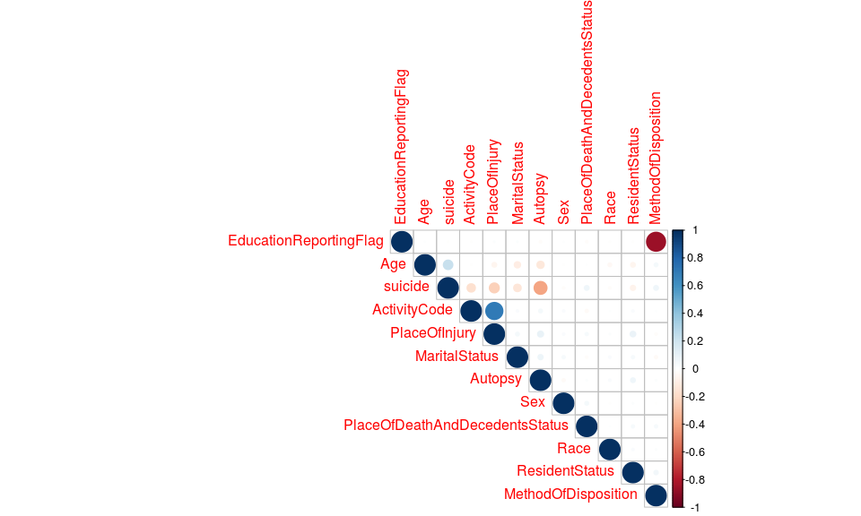

```r
corrplot(cor_mat, type="upper", order="hclust", sig.level = 0.01, insig ="blank")
```

۲. اثر هر یک از متغیرهای جنسیت، نژاد،آموزش، سن و نحوه تدفین را بر مرگ یا خودکشی ارزیابی کنید.

```r
cor.test(selecdted_data$suicide, selecdted_data$Sex)
```

```
    Pearson's product-moment correlation

data:  selecdted_data$suicide and selecdted_data$Sex
t = -4.9153, df = 59977, p-value = 8.888e-07
alternative hypothesis: true correlation is not equal to 0
95 percent confidence interval:
 -0.02806484 -0.01206539
sample estimates:
       cor
-0.0200664
```

```r
cor.test(selecdted_data$suicide, selecdted_data$Race)
```

```
    Pearson's product-moment correlation

data:  selecdted_data$suicide and selecdted_data$Race
t = -5.1604, df = 59977, p-value = 2.472e-07
alternative hypothesis: true correlation is not equal to 0
95 percent confidence interval:
 -0.02906472 -0.01306592
sample estimates:
        cor
-0.02106667
```

```r
cor.test(selecdted_data$suicide, selecdted_data$EducationReportingFlag)
```

```
    Pearson's product-moment correlation

data:  selecdted_data$suicide and selecdted_data$EducationReportingFlag
t = -2.7573, df = 59977, p-value = 0.00583
alternative hypothesis: true correlation is not equal to 0
95 percent confidence interval:
 -0.019259278 -0.003255408
sample estimates:
        cor
-0.01125806
```

```r
cor.test(selecdted_data$suicide, selecdted_data$Age)
```

```
    Pearson's product-moment correlation

data:  selecdted_data$suicide and selecdted_data$Age
t = 54.614, df = 59977, p-value < 2.2e-16
alternative hypothesis: true correlation is not equal to 0
95 percent confidence interval:
 0.2100186 0.2252663
sample estimates:
      cor
0.2176558
```

```r
cor.test(selecdted_data$suicide, selecdted_data$MethodOfDisposition)
```

```
    Pearson's product-moment correlation

data:  selecdted_data$suicide and selecdted_data$MethodOfDisposition
t = 15.247, df = 59977, p-value < 2.2e-16
alternative hypothesis: true correlation is not equal to 0
95 percent confidence interval:
 0.05415970 0.07010381
sample estimates:
       cor
0.06213572
```

۳. با استفاده از مدل رگرسیون لاجستیک یک مدل به داده ها برازش دهید و سپس آن را نقص یابی کنید.

```r
cor_mat[, c('suicide')] -> suicide_data
sort(suicide_data %>% abs , decreasing = TRUE)
```

```
                       suicide                        Autopsy
                          1.00                           0.40
                 PlaceOfInjury                            Age
                          0.24                           0.22
                  ActivityCode                  MaritalStatus
                          0.17                           0.14
                ResidentStatus PlaceOfDeathAndDecedentsStatus
                          0.07                           0.06
           MethodOfDisposition                            Sex
                          0.06                           0.02
                          Race         EducationReportingFlag
                          0.02                           0.01
```

```r
logmod2 = glm(suicide ~ Autopsy + PlaceOfInjury + Age + ActivityCode + MaritalStatus, data = death, family = binomial(link = 'logit'))
summary(logmod2)
```

```
Call:
glm(formula = suicide ~ Autopsy + PlaceOfInjury + Age + ActivityCode +
    MaritalStatus, family = binomial(link = "logit"), data = death)

Deviance Residuals:
    Min       1Q   Median       3Q      Max
-7.0999  -0.9302   0.1704   0.7745   3.2483

Coefficients:
                 Estimate Std. Error z value Pr(>|z|)
(Intercept)     3.9930665  0.0828249  48.211  < 2e-16 ***
AutopsyU       -2.9808641  0.1000367 -29.798  < 2e-16 ***
AutopsyY       -3.8606156  0.0663193 -58.213  < 2e-16 ***
PlaceOfInjury  -0.0400630  0.0014985 -26.736  < 2e-16 ***
Age             0.0224153  0.0007852  28.546  < 2e-16 ***
ActivityCode   -0.0100795  0.0015345  -6.569 5.08e-11 ***
MaritalStatusM  0.0518968  0.0348614   1.489    0.137
MaritalStatusS -0.7302621  0.0343814 -21.240  < 2e-16 ***
MaritalStatusU -0.6729649  0.0992722  -6.779 1.21e-11 ***
MaritalStatusW -0.3456242  0.0599411  -5.766 8.11e-09 ***
---
Signif. codes:  0 '***' 0.001 '**' 0.01 '*' 0.05 '.' 0.1 ' ' 1

(Dispersion parameter for binomial family taken to be 1)

    Null deviance: 71216  on 59978  degrees of freedom
Residual deviance: 51426  on 59969  degrees of freedom
AIC: 51446

Number of Fisher Scoring iterations: 7
```

۴. با استفاده از سه نمودار خروجی مدل را نسبت به داده واقعی ارزیابی کنید.

در این سوال یک بار مدل را بر اساس همه ی داده ها بدست آوردم و یک بار با حذف داده های پرت، و نتایج آن ها را با هم مقایسه کردم.

برای هر کمیت نمودار اول مربوط به همه ی داده ها است و نمودار دوم مربوط به داده های انتخاب شده.

همانطور که مشاهده می شود مدلی که از داده های انتخابی بدست می آید بسیار بهتر است.

```r
death %>% filter(PlaceOfInjury < 99) %>% filter(ActivityCode < 99) %>% filter(Age < 900)-> data
mylogit = glm(suicide ~ Autopsy + PlaceOfInjury + Age + ActivityCode + MaritalStatus, data = data, family = "binomial")
mylogit2 = glm(suicide ~ Autopsy + PlaceOfInjury + Age + ActivityCode + MaritalStatus, data = death, family = "binomial")

data %>% mutate(pred = fitted(mylogit)) -> pred_data
death %>% mutate(pred = fitted(mylogit2)) -> pred_data2
```

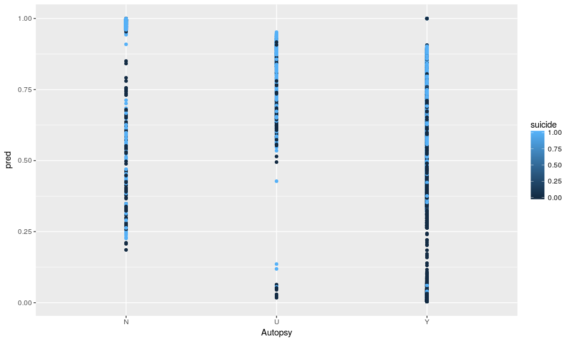

```r
ggplot(pred_data2, aes(x = Autopsy,y = pred,col = suicide))+
  geom_point()
```

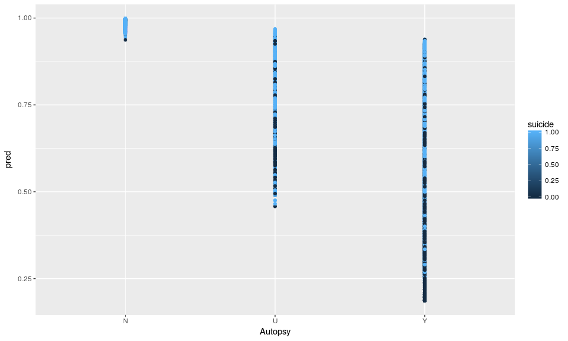

```r
ggplot(pred_data, aes(x = Autopsy,y = pred,col = suicide))+
  geom_point()
```

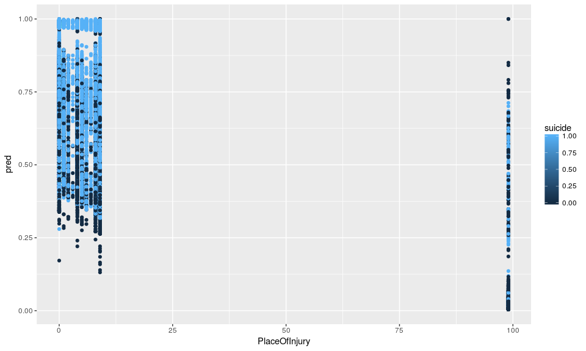

```r
ggplot(pred_data2, aes(x = PlaceOfInjury,y = pred,col = suicide))+
  geom_point()
```

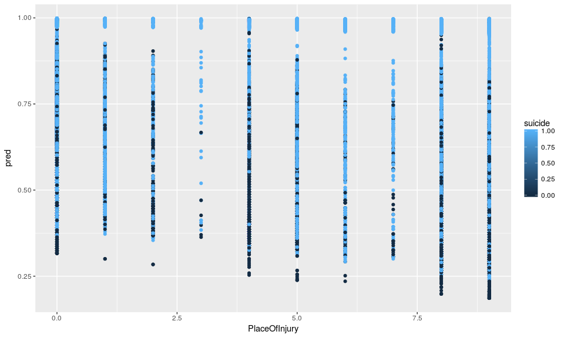

```r
ggplot(pred_data, aes(x = PlaceOfInjury,y = pred,col = suicide))+
  geom_point()
```

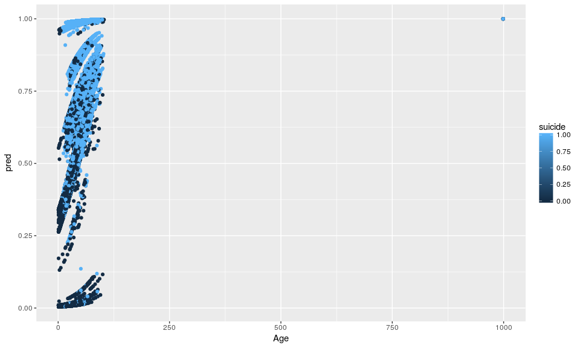

```r
ggplot(pred_data2, aes(x = Age,y = pred,col = suicide))+
  geom_point()
```

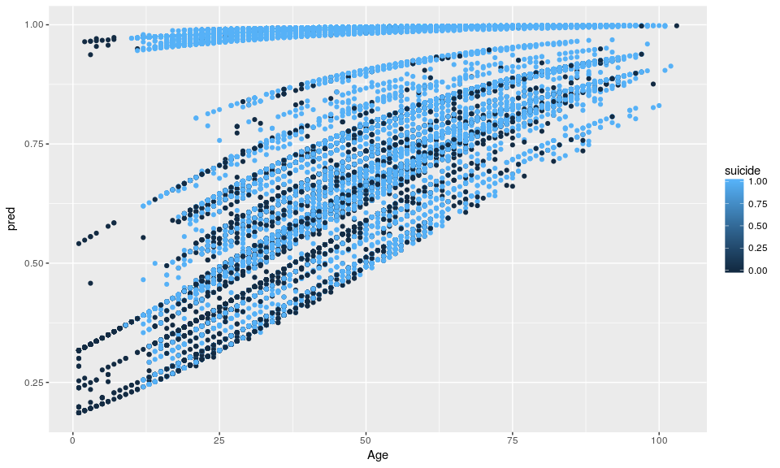

```r
ggplot(pred_data, aes(x = Age,y = pred,col = suicide))+
  geom_point()
```

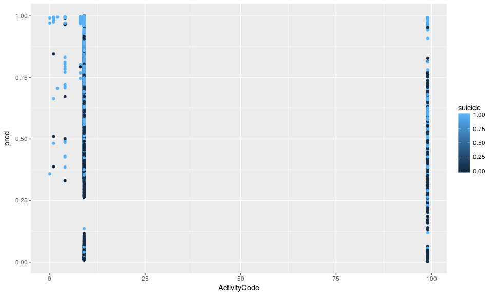

```r
ggplot(pred_data2, aes(x = ActivityCode,y = pred,col = suicide))+
  geom_point()
```

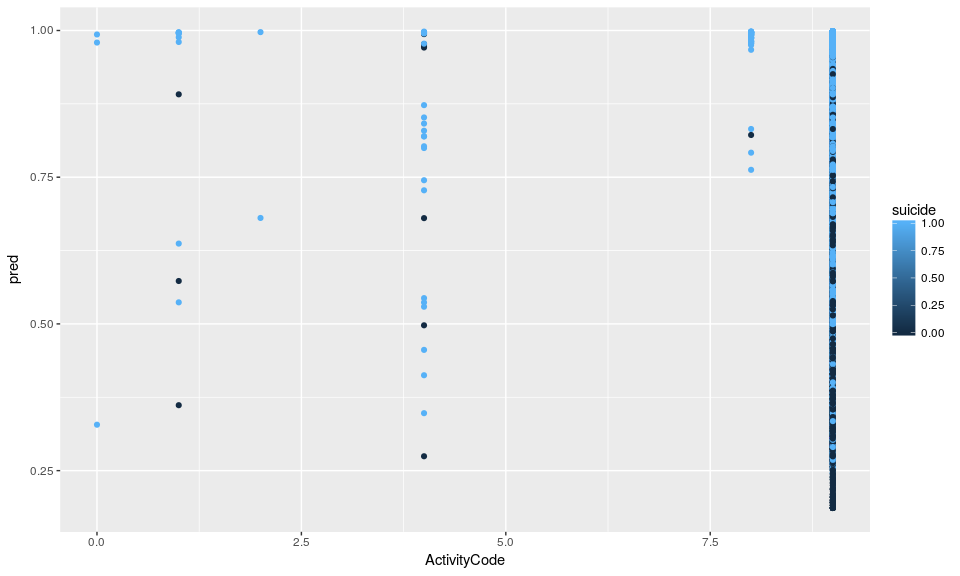

```r
ggplot(pred_data, aes(x = ActivityCode,y = pred,col = suicide))+
  geom_point()
```

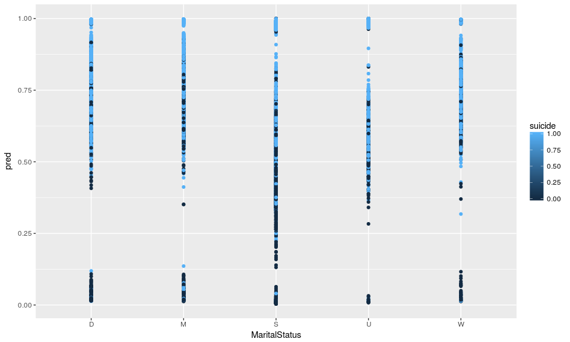

```r
ggplot(pred_data2, aes(x = MaritalStatus,y = pred,col = suicide))+
  geom_point()
```

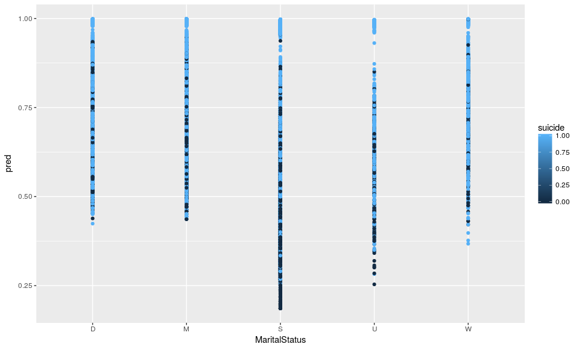

```r
ggplot(pred_data, aes(x = MaritalStatus,y = pred,col = suicide))+
  geom_point()
```

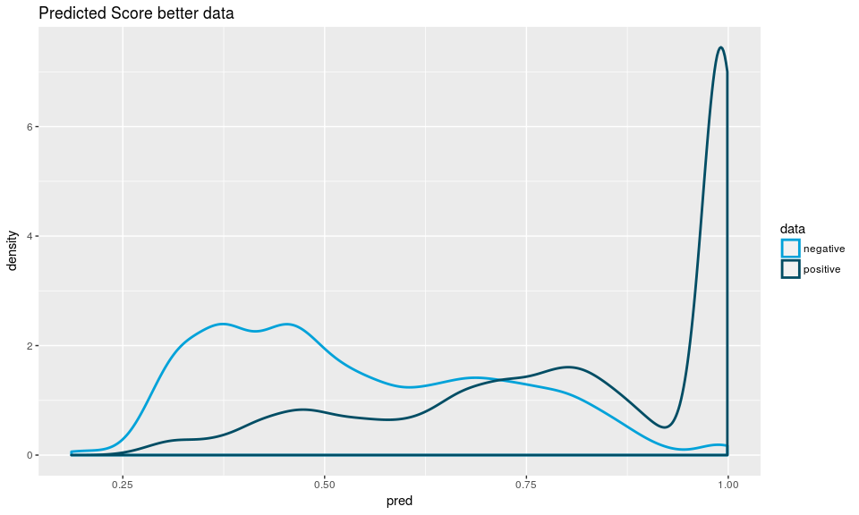

```r
ggplot( pred_data, aes( pred, color = as.factor(suicide))) +
geom_density( size = 1 ) +
ggtitle( "Predicted Score better data" ) +
scale_color_economist( name = "data", labels = c( "negative", "positive" ) )
```

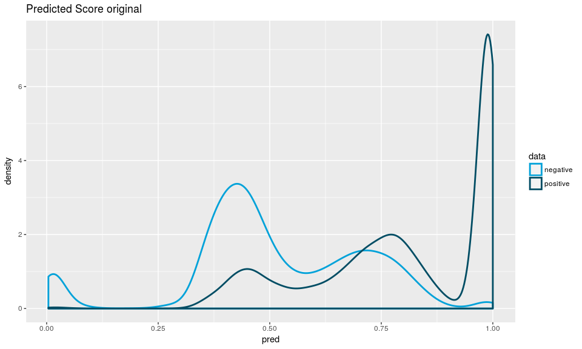

```r
ggplot( pred_data2, aes( pred, color = as.factor(suicide))) +
geom_density( size = 1 ) +
ggtitle( "Predicted Score original" ) +
scale_color_economist( name = "data", labels = c( "negative", "positive" ) )
```

۵. ابتدا ۲۰ درصد داده را به صورت تصادفی به عنوان تست در نظر بگیرید. مدل را با استفاده از ۸۰ درصد باقی مانده برازش دهید. با استفاده از پارامتر قطع ۰.۵ نتایج را برای داده تست پیش بینی کنید. سپس کمیت های زیر را محاسبه کنید.

- P: positive samples
- N: negative samples
- TP: true positive TP (eqv. with hit)
- TN: true negative (eqv. with correct rejection)
- FP: false positive (eqv. with false alarm, Type I error)
- FN: false negative (eqv. with miss, Type II error)
- Accuracy (ACC) ACC = (TP+TN)/(P+T)
- False positive rate (FPR): 1- TN/N
- True positive rate (TPR): TP/P

مشابه آنچه در کلاس گفته شد نمایشی از چهار کمیت TN, TP,FP,FN به همراه داده ها رسم نمایید.

```r
sample_size = floor(0.8*nrow(death))
train_index = sample(seq_len(nrow(death)), sample_size, replace = FALSE, prob = NULL)
train_data = death[train_index,]
test_data = death[-train_index,]
trainMod = glm(suicide ~ Autopsy + PlaceOfInjury + Age + ActivityCode + MaritalStatus, data = train_data, family = binomial(link = 'logit'))
summary(trainMod)
```

```
Call:
glm(formula = suicide ~ Autopsy + PlaceOfInjury + Age + ActivityCode +
    MaritalStatus, family = binomial(link = "logit"), data = train_data)

Deviance Residuals:
    Min       1Q   Median       3Q      Max
-7.2688  -0.9296   0.1702   0.7807   3.2034

Coefficients:
                 Estimate Std. Error z value Pr(>|z|)
(Intercept)     3.9094765  0.0922805  42.365  < 2e-16 ***
AutopsyU       -3.0294859  0.1106361 -27.382  < 2e-16 ***
AutopsyY       -3.8558346  0.0739572 -52.136  < 2e-16 ***
PlaceOfInjury  -0.0401881  0.0016423 -24.471  < 2e-16 ***
Age             0.0236740  0.0008786  26.945  < 2e-16 ***
ActivityCode   -0.0096555  0.0017157  -5.628 1.83e-08 ***
MaritalStatusM  0.0563510  0.0387720   1.453    0.146
MaritalStatusS -0.6938676  0.0382221 -18.154  < 2e-16 ***
MaritalStatusU -0.6825007  0.1094277  -6.237 4.46e-10 ***
MaritalStatusW -0.3892486  0.0663103  -5.870 4.36e-09 ***
---
Signif. codes:  0 '***' 0.001 '**' 0.01 '*' 0.05 '.' 0.1 ' ' 1

(Dispersion parameter for binomial family taken to be 1)

    Null deviance: 57186  on 47982  degrees of freedom
Residual deviance: 41349  on 47973  degrees of freedom
AIC: 41369

Number of Fisher Scoring iterations: 7
```

```r
train_data$pred = ifelse(predict(trainMod, train_data, type = 'response') > 0.5, 1, 0)
test_data$pred  = ifelse(predict(trainMod, test_data, type = 'response') > 0.5, 1, 0)

train_data$prediction = predict(trainMod, train_data, type = 'response')
test_data$prediction  = predict(trainMod, test_data, type = 'response')

nrow(test_data %>% filter(pred==1)) -> P
P
```

```
[1] 9131
```

```r
nrow(test_data %>% filter(pred==0)) -> N
N
```

```
[1] 2865
```

```r
nrow(test_data %>% filter(pred==suicide & pred==1)) -> TP
TP
```

```
[1] 7694
```

```r
nrow(test_data %>% filter(pred==suicide & pred==0)) -> TN
TN
```

```
[1] 1817
```

```r
nrow(test_data %>% filter(pred!=suicide & pred==1)) -> FP
FP
```

```
[1] 1437
```

```r
nrow(test_data %>% filter(pred!=suicide & pred==0)) -> FN
FN
```

```
[1] 1048
```

```r
(TP+TN)/(P+T) -> ACC
ACC
```

```
[1] 1.041502
```

```r
1 - TN/N -> FPR
FPR
```

```
[1] 0.3657941
```

```r
TP/P -> TPR
TPR
```

```
[1] 0.842624
```

۶. نمودار صحت مدل (accuracy) را بر حسب مقادیر مختلف قطع برای داده تست رسم نمایید. کدام پارامتر قطع بالاترین صحت را در پیش بینی داراست؟

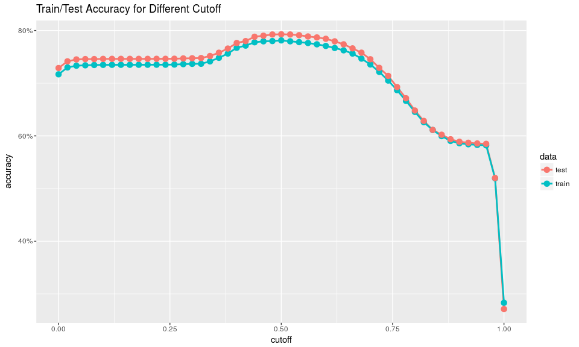

```r
accuracy_info = AccuracyCutoffInfo( train = train_data, test = test_data,
                                     predict = "prediction", actual = "suicide" )
accuracy_info$plot
```

همانطور که مشاهده میشود 0.5 بهترین پارامتر قطع است.

۷. نمودار ROC را برای داده های قسمت قبل رسم نمایید. همچنین نقطه مربوط به بهترین پارامتر قطع را مشخص نمایید.

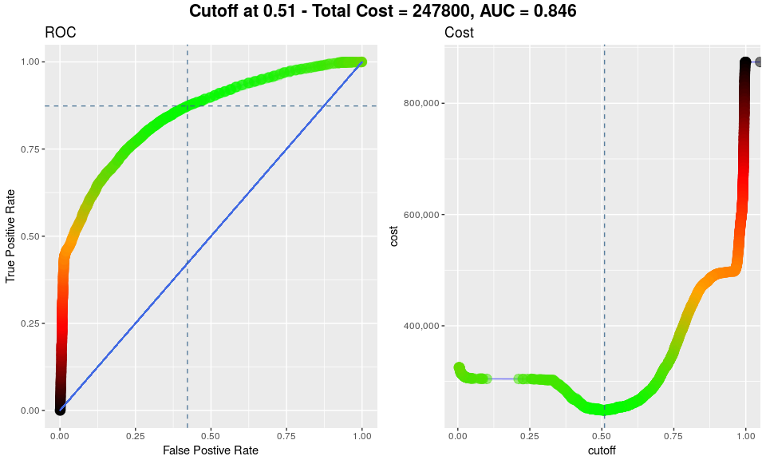

```r
cost_fp = 100
cost_fn = 100
roc_info = ROCInfo( data = test_data, predict = "prediction",
                     actual = "suicide", cost.fp = cost_fp, cost.fn = cost_fn )
grid.draw(roc_info$plot)
```

۸. با قرار دادن کمیت nfolds = 5 و با استفاده از H20 مدل مساله را بسازید و نتیجه حاصل را ارزیابی کنید.

```r
hdata = as.h2o(death)
chglm = h2o.glm(y = "suicide", x= c('Autopsy', 'PlaceOfInjury', 'Age', 'ActivityCode', 'MaritalStatus'),
               training_frame = hdata, family="binomial",nfolds = 5)
chglm
```

```
Model Details:
==============

H2OBinomialModel: glm
Model ID:  GLM_model_R_1524855475590_73
GLM Model: summary
    family  link                                regularization
1 binomial logit Elastic Net (alpha = 0.5, lambda = 2.185E-4 )
  number_of_predictors_total number_of_active_predictors
1                         11                          10
  number_of_iterations training_frame
1                    5          death

Coefficients: glm coefficients
             names coefficients standardized_coefficients
1        Intercept     0.855767                  1.558530
2  MaritalStatus.D     0.347543                  0.347543
3  MaritalStatus.M     0.401348                  0.401348
4  MaritalStatus.S    -0.372986                 -0.372986
5  MaritalStatus.U    -0.231333                 -0.231333
6  MaritalStatus.W     0.000000                  0.000000
7        Autopsy.N     2.675226                  2.675226
8        Autopsy.U    -0.154140                 -0.154140
9        Autopsy.Y    -1.080923                 -1.080923
10             Age     0.022449                  0.563446
11    ActivityCode    -0.009865                 -0.121514
12   PlaceOfInjury    -0.039430                 -0.593675

H2OBinomialMetrics: glm
** Reported on training data. **

MSE:  0.1423007
RMSE:  0.3772276
LogLoss:  0.4287358
Mean Per-Class Error:  0.3468753
AUC:  0.8397382
Gini:  0.6794764
R^2:  0.2953178
Residual Deviance:  51430.29
AIC:  51452.29
```

[output cut: 70 more lines]

```
---
                        mean           sd cv_1_valid cv_2_valid cv_3_valid
precision         0.78517866 0.0065893205  0.8003391   0.791482 0.77977085
r2                 0.2948131 0.0035814869  0.2964593 0.30212817  0.2894004
recall            0.95048505  0.008732864  0.9328141  0.9428375   0.963896
residual_deviance  10294.799    110.25472  10103.604  10295.495  10242.456
rmse              0.37733966  0.001616931  0.3761202 0.37525815 0.37687883
specificity       0.33291706  0.031180896 0.39807576 0.36259204  0.2863664
                  cv_4_valid cv_5_valid
precision         0.77535087  0.7789504
r2                0.29730833 0.28876936
recall             0.9648392  0.9480383
residual_deviance   10253.77  10578.668
rmse              0.37666744 0.38177368
specificity        0.2836396 0.33391154
```

۹. آیا ما میتوانیم سرویسی به قضات ارایه کنیم تا با استفاده از اطلاعات مرگ بتوانند موارد مشکوک به قتل را از خودکشی تفکیک دهند؟

بله کافیست مدل بدست آمده را وی آن داده ها فیت کنیم و مقدار پیشبینی شده را بدست آوریم.